# Tutorial 12 Question 1

Kate Vendrely

11/17/2017

### Question 1

1. Generally describe the dataset in “chickwts.txt”

First, let’s load the data and save it as “chick”:

```r
chick=read.table("chickwts.txt",sep=",",header = TRUE)
```

We can see that we have a table with 2 columns and 72 rows (two of which are headers). The **weight** of the chicks are in the first column and the **feed type** are in the second column.

2. Generate a plot that summarizes all of the data in “chickwts.txt”

Now that we know what the data looks like in a table, let’s look at it graphically using a boxplot:

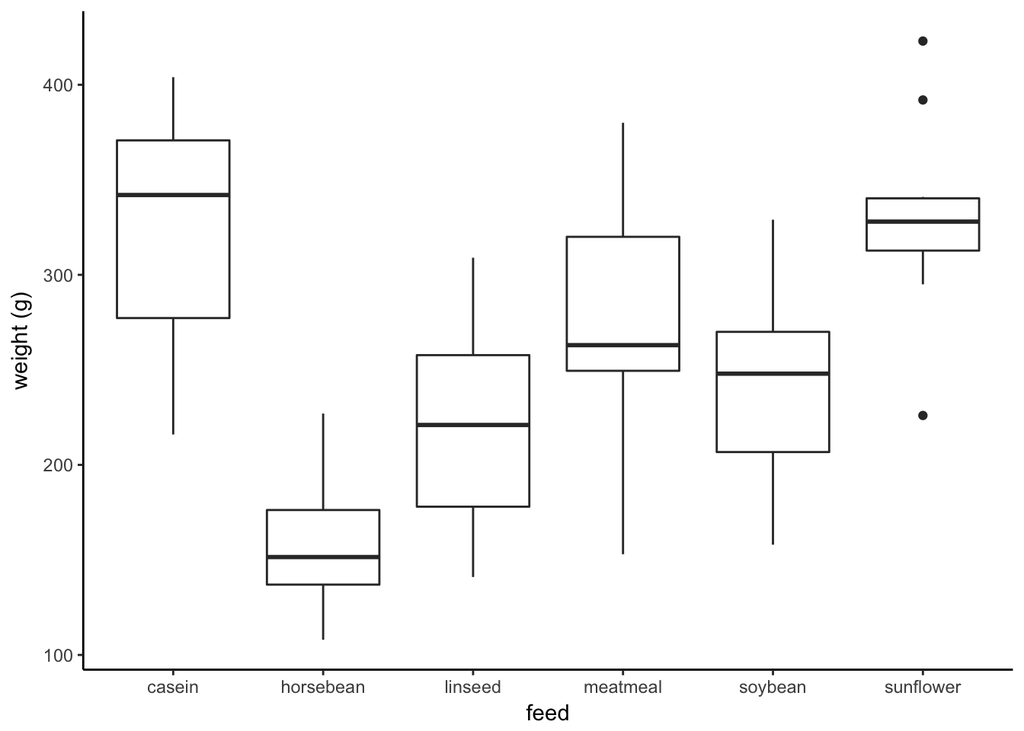

```r
library(ggplot2)
a = ggplot(data = chick, aes(x = feed, y = weight))
a + geom_boxplot() + theme_classic() + xlab("feed") + ylab("weight (g)")
```

3. State a *null and alternative hypothesis for the difference in chick weights when fed soybean vs. sunflower feed*

Now that we know what the data looks like, let’s see if there is a difference in **chick weights** when fed **soybeans** versus those fed with **sunflower seeds.**

```r
nllike1=function(p,x,y){
  B0=p[1]
  B1=p[2]
  sigma=exp(p[3])

  expected=B0+B1*x

  nll=-sum(dnorm(x=y,mean=expected,sd=sigma,log=TRUE))
  return(nll)
}

nllike2 <- function(p,x,y){
  B0=p[1]
  B1=p[2]
  sigma = exp(p[3])
  expected = B0+B1*x

  nll = -sum(dnorm(y, mean=expected, sd=sigma, log=TRUE))
  return(nll)
}
```

Now before we can test our *hypotheses to determine whether there is a difference in chick **weights** between those that were **fed soybean or sunflower** seeds,* we have to take all of the data and subset it to have only the chicks **fed soybean or sunflowers** in our data set and then change soybean to “0” and sunflowers to “1” so our test can recognize the differences between the *feed types*.

To do this:

```r
soybean <- chick[which(chick$feed=="soybean"),]
soybean[,2] <- 0
sunflower <- chick[which(chick$feed=="sunflower"),]
sunflower[,2] <- 1
subChicks <- rbind(soybean,sunflower)
```

4. Test the *null hypothesis* above using a likelihood ratio test using the subset **soybean and sunflower seed fed** chicks data.

Now that we have the custom functions for the *null and alternative hypothese*s, let’s test the null hypothesis using a likelihood ratio test:

```r
#estimate parameters by minimizing the NLL. Can estimate intital parameters by using the mean of the subChick weights
mean(subChicks$weight)
```

```
## [1] 284.5
```

```r
Guess = c(1,1,1)

#test the null hypothesis with a likelihood ratio test
fit1=optim(Guess, nllike1, x=soybean$weight, y=soybean$feed)
fit2=optim(Guess, nllike2, x=sunflower$weight, y=sunflower$feed)
fit1$value
```

```
## [1] 19.7065
```

```r
fit2$value
```

```
## [1] -10.31952
```

```r
D = 2*(fit1$value-fit2$value)
pchisq(D, df=1, lower.tail=F)
```

```
## [1] 9.238241e-15
```

5. Interpret the results of the likelihood ratio test.

The p-value given by the model is 9.23e-15 (statistically significant), so the null hypothesis can be rejected. Therefore, feeding the chicks the **soybean or the sunflower seeds** does signficantly change the **chick’s weight.**